# Manipulation et prétraitement de données - UE1

Première manipulation d’un jeu de données (exercice n°1)

Francisco Martin-Gomez

juillet-août 2023

## Environnement de travail

```r
library(dplyr)
library(ggplot2)
library(grid)
library(gridExtra)
library(ggpubr)
library(cowplot)
library(readr)
```

Pour réaliser cet exercice, les packages suivants ont été utilisés (le numéro de la version est entre parenthèse): ggplot2 (3.4.2), dplyr (1.1.2), grid (4.3.1), gridExtra (2.3), ggpubr (0.6.0), cowplot (1.1.1), readr (2.1.4).

```r
blue_theme <- function() {
  theme(
    # add border
    panel.border = element_rect(colour = "blue", fill = NA, linetype = 2),
    # color background
    panel.background = element_rect(fill = "aliceblue"),
    # modify grid
    panel.grid.major.x = element_line(colour = "steelblue", linetype = 3, linewidth = 0.5),
    panel.grid.minor.x = element_blank(),
    panel.grid.major.y =  element_line(colour = "steelblue", linetype = 3, linewidth = 0.5),
    panel.grid.minor.y = element_blank(),
    # modify text, axis and colour
    axis.text = element_text(colour = "steelblue", face = "italic"),
    axis.title = element_text(colour = "steelblue"),
    axis.ticks = element_line(colour = "steelblue"),
    # text elements
    plot.title = element_text(size = 14, colour = "steelblue", face = 'bold', hjust = 0, vjust = 2),
    plot.subtitle = element_text(size = 12),
    plot.caption = element_text(size = 9, hjust = 1),
    # legend at the bottom
    legend.position = "bottom"
  )
}
```

## 1. DATASET

### Importation du dataset

```r
df1 <- read.csv("age_gender.csv", header = TRUE, sep = ";")
```

### Présentation du dataset

Le jeu de données `age_gender` propose deux variables (age et genre), toutes deux de type entier. La variable `age` retrace l’âge des personnes (minimum = 1, maximum = 116, Moyenne = 33.3), et la variable genre possède deux valeurs possibles (0 ou 1). Cette dernière est ainsi une variable binaire ou bouléenne.

```r
str(df1)
```

```
## 'data.frame':    23705 obs. of  2 variables:
##  $ age  : int  1 1 1 1 1 1 1 1 1 1 ...
##  $ genre: int  0 0 0 0 0 0 0 0 0 0 ...
```

```r
summary(df1)
```

```
##       age            genre
##  Min.   :  1.0   Min.   :0.0000
##  1st Qu.: 23.0   1st Qu.:0.0000
##  Median : 29.0   Median :0.0000
##  Mean   : 33.3   Mean   :0.4773
##  3rd Qu.: 45.0   3rd Qu.:1.0000
##  Max.   :116.0   Max.   :1.0000
```

Le dataset contient 23705 observations.

### Prétraitement : recodage de la variable `genre`

Pour les besoins de l’exercice, la variable `genre` est recodée (en variable caractère) pour faire apparaître les deux genres “Homme et”Femme”. Une nouvelle variable est ainsi crée : `genre_label`

```r
df1$genre_label <- ifelse(df1$genre == 0, "Femme", "Homme")
str(df1)
```

```
## 'data.frame':    23705 obs. of  3 variables:
##  $ age        : int  1 1 1 1 1 1 1 1 1 1 ...
##  $ genre      : int  0 0 0 0 0 0 0 0 0 0 ...
##  $ genre_label: chr  "Femme" "Femme" "Femme" "Femme" ...
```

```r
df1
```

| age | genre | genre_label |
| --- | --- | --- |
| 1 | 0 | Femme |
| 1 | 0 | Femme |
| 1 | 0 | Femme |
| 1 | 0 | Femme |
| 1 | 0 | Femme |
| 1 | 0 | Femme |
| 1 | 0 | Femme |
| 1 | 0 | Femme |
| 1 | 0 | Femme |
| 1 | 0 | Femme |

[output cut: 9990 more lines]

## Distribution de `age` par séquences de 5 ans avec la fonction `cut`

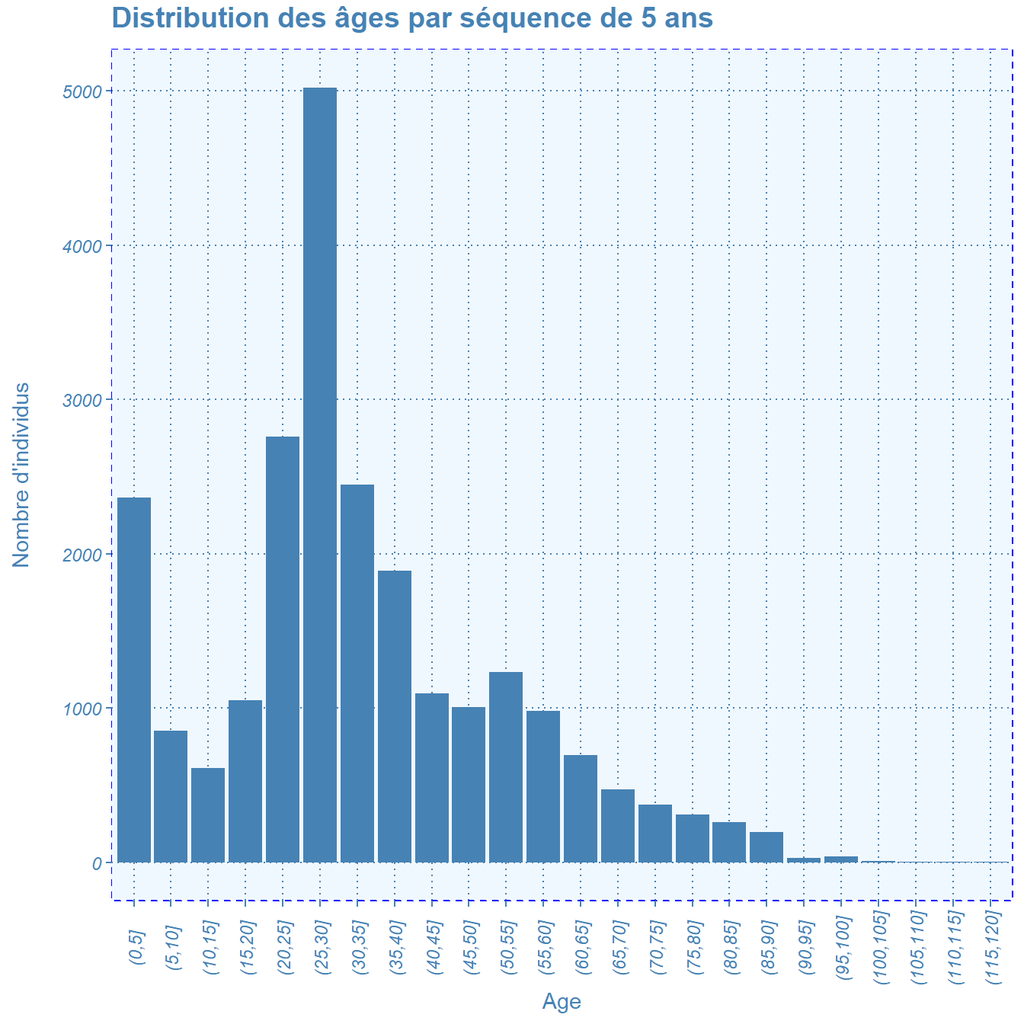

```r
# Utiliser la fonction cut pour couper l'âge des individus par séquences de cinq ans
df1 <- df1 %>%
  mutate(age_group = cut(age, breaks = seq(0, 120, 5))) # la séquence est initiée 0 et finie à 120 pour éviter la présence de NA

# Afficher la distribution des âges (pas de 5 ans)
ggplot(df1, aes(x = age_group)) +
  geom_bar(fill="steelblue") +
  blue_theme() +
  xlab("Age") +
  ylab("Nombre d'individus\n") +
  ggtitle("Distribution des âges par séquence de 5 ans") +
  theme(axis.text.x = element_text(angle = 90, vjust = 0.5))
```

## Présentation de la distribution de `age` et `genre` sur un même graphique (sous la forme de deux subplots)

### Les deux subplots ensemble

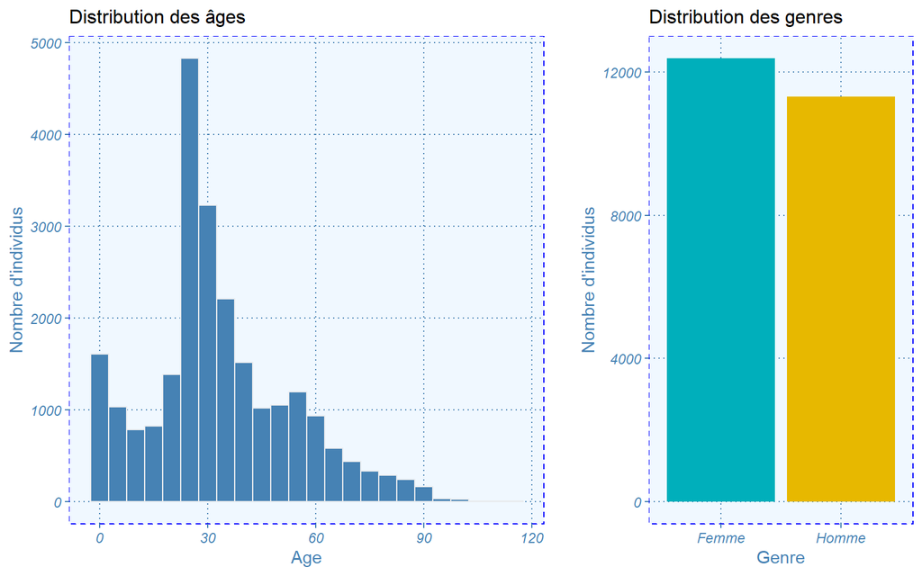

```r
# Représenter la distribution des deux variables (âge et genre) sur un même graphique avec deux sous-graphiques
# Subplot pour l'âge
p1 <- ggplot(df1, aes(x = age)) +
  geom_histogram(color="#e9ecef", fill="steelblue", binwidth=5) +
  blue_theme() +
  xlab("Age") +
  ylab("Nombre d'individus") +
  labs(subtitle = "Distribution des âges")

# Subplot pour le genre
p2 <- ggplot(df1, aes(x = factor(genre_label), fill = genre_label)) +
  geom_bar() +
  blue_theme() +
  xlab("Genre") +
  ylab("\nNombre d'individus") +
  labs(subtitle = "Distribution des genres") +
  scale_fill_manual(values = c("#00AFBB", "#E7B800")) +
  theme(legend.position = "none")


# Combinaison des deux subplots
plot_grid(p1, p2, rel_widths = c(1.5, 1))
```

### Ajout d’un titre à la figure

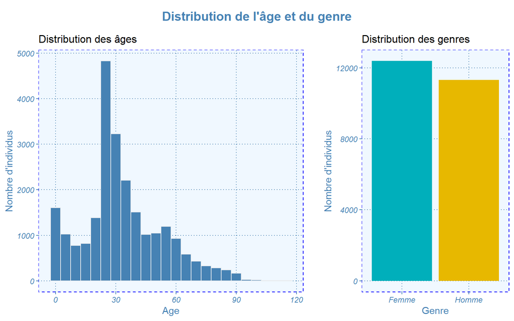

```r
#Ajouter un titre
p1_p2_combined <- plot_grid(p1, p2, rel_widths = c(1.5, 1))

grid.arrange(p1_p2_combined, top = text_grob("\n"),clip = FALSE)
grid.text("Distribution de l'âge et du genre", x = 0.5, y = 0.95, hjust = 0.5, gp = gpar(fontsize = 14, fontface = "bold", col = "steelblue"))
```

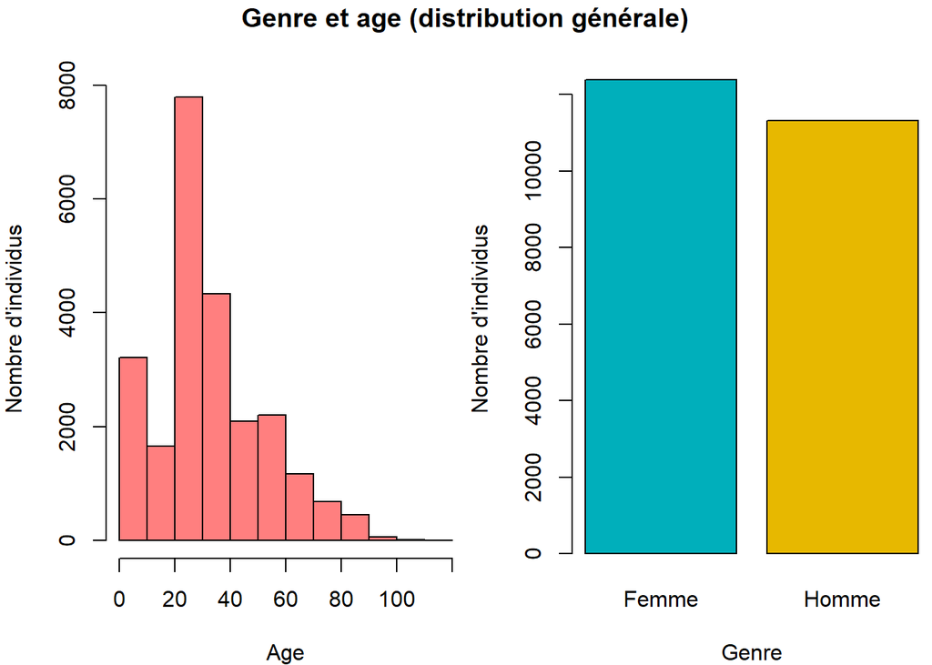

```r
#Figure conjointe de deux graphiques indépendants (subplots)
value_genre <- df1 %>%
  group_by(genre_label) %>%
  count()


par(
  mfrow=c(1,2),    # Configurer la fenêtre graphique pour afficher deux graphiques côte à côte
  mar=c(4,4,1,0)
)

hist(df1$age, col=rgb(1,0,0,0.5) , xlab="Age" , ylab="Nombre d'individus" , main="" )
barplot(value_genre$n, beside = TRUE, col =  c("#00AFBB", "#E7B800"), # Couleurs manuelles pour les bars
        xlab = "Genre", ylab = "Nombre d'individus",
        names.arg = value_genre$genre_label)



# Configurer les paramètres de la fenêtre graphique
par(
  mfrow = c(1, 2),     # Configurer la fenêtre graphique pour afficher deux graphiques côte à côte
  mar = c(4, 4, 3, 0)  # Augmenter la marge supérieure pour le titre général
)

# Tracer l'histogramme
hist(df1$age, col = rgb(1, 0, 0, 0.5), xlab = "Age", ylab = "Nombre d'individus", main = "")

# Tracer le barplot
barplot(value_genre$n, beside = TRUE, col = c("#00AFBB", "#E7B800"),
        xlab = "Genre", ylab = "Nombre d'individus",
        names.arg = value_genre$genre_label)

# Ajouter un titre général pour les deux graphiques
title("Genre et age (distribution générale)", outer = TRUE, line = -1)  # 'outer = TRUE' indique que le titre doit être placé en dehors des deux graphiques
```

## Distribution de l’âge des individus par genre

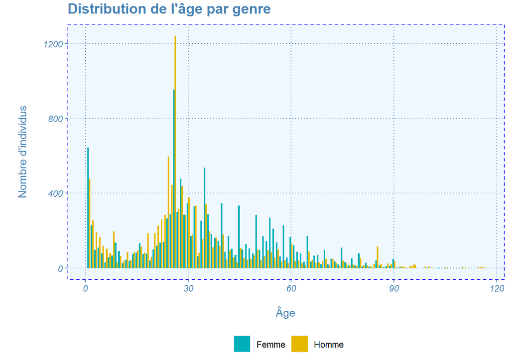

```r
ggplot(df1, aes(x = age, y = after_stat(count), fill = genre_label)) +
  geom_bar(position = position_dodge()) +
  blue_theme() +
  xlab("\nÂge") +
  ylab("\nNombre d'individus\n") +
  ggtitle("Distribution de l'âge par genre") +
  scale_fill_manual(values = c("#00AFBB","#E7B800")) +    # Utiliser les couleurs spécifiées
  scale_color_manual(values = c("#00AFBB","#E7B800")) +   # Utiliser les couleurs spécifiées
  labs(fill = "") +
  labs(color = "")
```

### Représentation avec courbe de densité et histogramme, sous condition de transparence

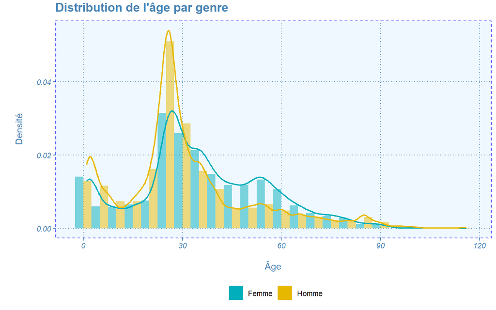

```r
ggplot(df1, aes(x = age, y = after_stat(density))) +
  geom_histogram(aes(fill = genre_label), position = position_dodge(),alpha = 0.5, binwidth = 5) +
  geom_density(aes(y = after_stat(density), color = genre_label), linewidth = 0.75) +
  blue_theme() +
  xlab("\nÂge") +
  ylab("\nDensité\n") +
  ggtitle("Distribution de l'âge par genre") +
  scale_fill_manual(values = c("#00AFBB","#E7B800")) +    # Utiliser les couleurs spécifiées
  scale_color_manual(values = c("#00AFBB","#E7B800")) +   # Utiliser les couleurs spécifiées
  labs(fill = "") +
  labs(color = "")
```

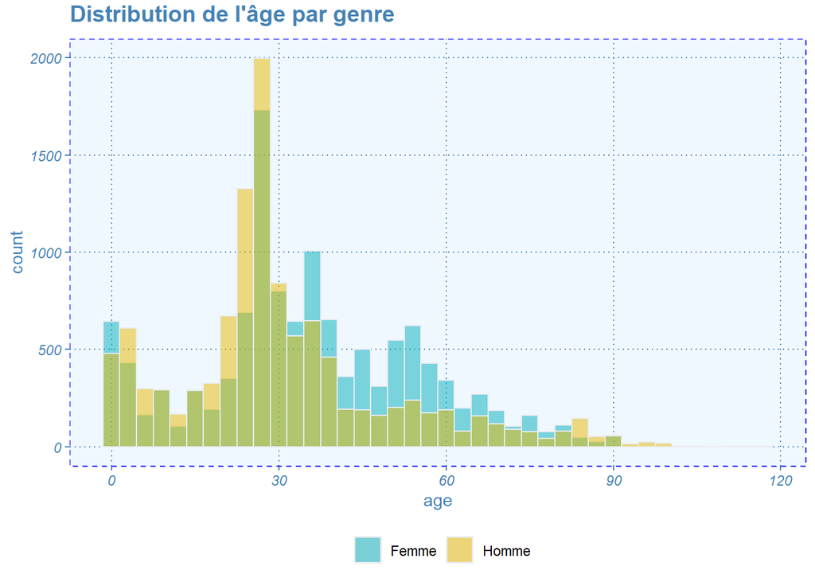

```r
ggplot(df1, aes(x = age, fill=genre_label)) +
    geom_histogram( color="#e9ecef", alpha=0.5, position = 'identity', binwidth = 3) +
    scale_fill_manual(values = c("#00AFBB","#E7B800")) +
    ggtitle("Distribution de l'âge par genre") +
    labs(fill="") +
    blue_theme()
```

## Barplot de l’âge moyen des hommes et des femmes avec barre d’erreur (écart-type)

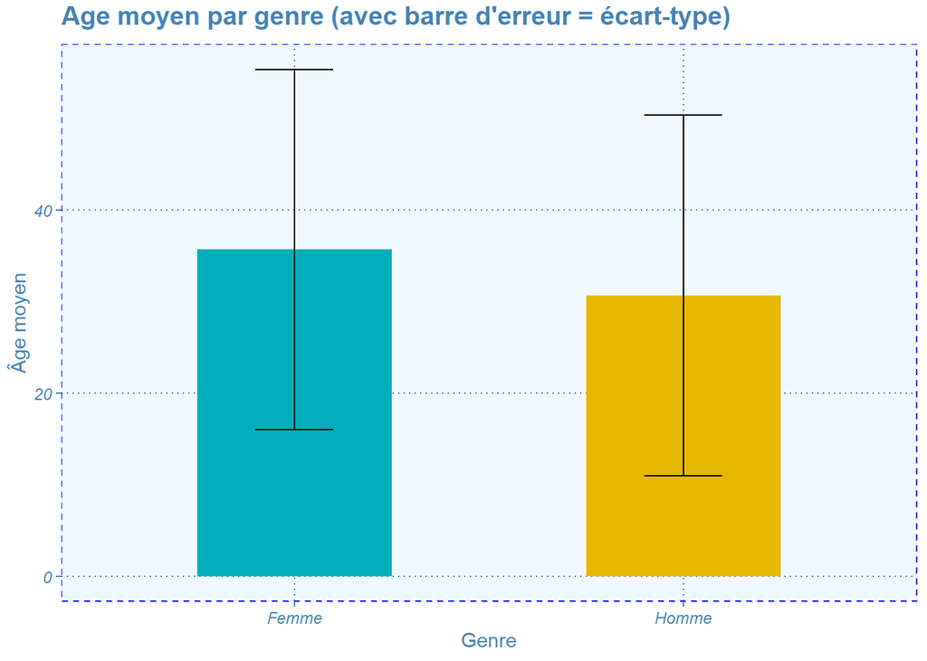

```r
age_means <- df1 %>%
  group_by(genre_label) %>%
  summarize(mean_age = mean(age),
            sd_age = sd(age))

# Barplot avec barres d'erreur représentant l'écart-type
ggplot(age_means, aes(x = genre_label, y = mean_age, fill = genre_label)) +
  geom_bar(stat = "identity", position = "dodge", width = 0.5) +
  geom_errorbar(aes(ymin = mean_age - sd_age, ymax = mean_age + sd_age),
                width = 0.2, position = position_dodge(width = 0.5)) +
  blue_theme() +
  xlab("Genre") +
  ylab("Âge moyen") +
  ggtitle("Age moyen par genre (avec barre d'erreur = écart-type)") +
  scale_fill_manual(values = c("#00AFBB","#E7B800")) +
  theme(legend.position = "none")
```